# NYPD Shooting Incidents

Taya Prince

2022-07-29

### Installing packages

Click below to see the code to install necessary packages.

**Code**

```r
install.packages('tidyverse')
install.packages('lubridate')
install.packages("gridExtra")
library(tidyverse)
library(lubridate)
library(gridExtra)
#This setting disables a notification from the summarise function that is redundant in this case
options(dplyr.summarise.inform = FALSE)
```

### Importing dataset

```r
nypd_url = "https://data.cityofnewyork.us/api/views/833y-fsy8/rows.csv?accessType=DOWNLOAD"

df = read_csv(nypd_url, show_col_types = FALSE)
```

### Exploring dataset

Below we are looking at the data types in all columns. We can see that the column ‘OCCUR_DATE’ is a string while it should be a date. We will correct this below. out of all columns, we will only be looking at certain ones, so we will be excluding a couple columns. We will also turn the age group columns into ordered factors.

```r
spec(df)
```

[output not shown]

Click below to see the code used to perform the mentioned manipulations.

**Code**

```r
df = df %>%
  select(c("OCCUR_DATE",
           "OCCUR_TIME",
           "BORO",
           "STATISTICAL_MURDER_FLAG",
           "PERP_AGE_GROUP",
           "PERP_SEX",
           "PERP_RACE",
           "VIC_AGE_GROUP",
           "VIC_SEX",
           "VIC_RACE")) %>%
  mutate(OCCUR_DATE = mdy(OCCUR_DATE))

df$PERP_AGE_GROUP = factor(df$PERP_AGE_GROUP, levels = c("<18", "18-24", "25-44", "45-64", "65+", "UNKNOWN"))
df$VIC_AGE_GROUP = factor(df$VIC_AGE_GROUP, levels = c("<18", "18-24", "25-44", "45-64", "65+", "UNKNOWN"))
df$PERP_RACE = factor(df$PERP_RACE)
df$PERP_SEX = factor(df$PERP_SEX)
df$VIC_RACE = factor(df$VIC_RACE)
df$VIC_SEX = factor(df$VIC_SEX)
df$BORO = factor(df$BORO)
```

```r
df
```

```
## # A tibble: 25,596 × 10
##    OCCUR_DATE OCCUR_TIME BORO    STATI…¹ PERP_…² PERP_…³ PERP_…⁴ VIC_A…⁵ VIC_SEX
##    <date>     <time>     <fct>   <lgl>   <fct>   <fct>   <fct>   <fct>   <fct>
##  1 2006-08-27 05:35      BRONX   TRUE    <NA>    <NA>    <NA>    25-44   F
##  2 2011-03-11 12:03      QUEENS  FALSE   <NA>    <NA>    <NA>    65+     M
##  3 2021-04-14 21:08      BRONX   TRUE    <NA>    <NA>    <NA>    18-24   M
##  4 2021-12-10 19:30      BRONX   FALSE   <NA>    <NA>    <NA>    25-44   M
##  5 2021-02-22 00:18      MANHAT… FALSE   <NA>    <NA>    <NA>    25-44   M
##  6 2021-03-07 06:15      BROOKL… TRUE    25-44   M       BLACK … 25-44   M
##  7 2021-07-21 00:40      MANHAT… FALSE   25-44   M       BLACK   25-44   M
##  8 2021-09-11 20:20      MANHAT… FALSE   <NA>    <NA>    <NA>    18-24   M
##  9 2021-05-09 02:50      BRONX   TRUE    25-44   M       BLACK   25-44   M
## 10 2021-04-23 13:25      BROOKL… FALSE   <NA>    <NA>    <NA>    18-24   M
## # … with 25,586 more rows, 1 more variable: VIC_RACE <fct>, and abbreviated
## #   variable names ¹STATISTICAL_MURDER_FLAG, ²PERP_AGE_GROUP, ³PERP_SEX,
## #   ⁴PERP_RACE, ⁵VIC_AGE_GROUP
## # ℹ Use `print(n = ...)` to see more rows, and `colnames()` to see all variable names
```

### Incidents in the different boroughs

*The map below was made in and embedded from [Tableau](https://public.tableau.com).*

[figure not shown]

### Analysis of data set

I would like to see if perpetrators preferably attack victims of the same race as themselves. To see this, we need to group the data set by perpetrator and victim race, as done below.

**Expand here to see the code**

```r
#creating two new dfs: grouped by perpetrator race and grouped by both perp. and vic. race
by_race_df = df[!(is.na(df$PERP_RACE)),] %>%
  group_by(PERP_RACE, VIC_RACE) %>%
  summarise(incidents = n())

by_perprace_df = df[!(is.na(df$PERP_RACE)),] %>%
  group_by(PERP_RACE) %>%
  summarise(incidents = n())

#creating new df containing incidents only when victim is same race as perpetrator
same_race = by_race_df[by_race_df$PERP_RACE==by_race_df$VIC_RACE,]

#merging the above two new dfs and deleting them
merged = merge(by_perprace_df, same_race, by = "PERP_RACE", all.x = TRUE)
rm(by_perprace_df)
rm(same_race)
rm(by_race_df)

#deleting VIC_RACE, not needed
merged = subset(merged, select = -VIC_RACE)

#renaming columns
merged = rename(merged, incidents = incidents.x, VIC_RACE_SAME = incidents.y)

#replacing NA with 0
merged = replace(merged, is.na(merged), 0)

#calculating 'other' column
merged$VIC_RACE_DIFF = with(merged, merged$incidents - merged$VIC_RACE_SAME)

#changing absolute values to percent
merged$VIC_RACE_SAME = merged$VIC_RACE_SAME/merged$incidents
merged$VIC_RACE_DIFF = merged$VIC_RACE_DIFF/merged$incidents

#remove Unknown

merged = merged[!merged$PERP_RACE=='UNKNOWN',]
```

The table shows attackers grouped by race, the number of incidents for this racial group, and the percent of cases where the victim was of the same racial background, or of a different one.

```r
merged
```

```
##                        PERP_RACE incidents VIC_RACE_SAME VIC_RACE_DIFF
## 1 AMERICAN INDIAN/ALASKAN NATIVE         2     0.0000000     1.0000000
## 2       ASIAN / PACIFIC ISLANDER       141     0.3049645     0.6950355
## 3                          BLACK     10668     0.7940570     0.2059430
## 4                 BLACK HISPANIC      1203     0.2660017     0.7339983
## 6                          WHITE       272     0.5735294     0.4264706
## 7                 WHITE HISPANIC      2164     0.4283734     0.5716266
```

### Creating Vizualisations

**Click here to see the code used to create visualizations**

```r
##############################
#pie chart races perp and vic#
##############################
temp = df[!(is.na(df$PERP_RACE)|df$PERP_RACE=="UNKNOWN"),] %>% group_by(PERP_RACE) %>% summarise(incidents = n())
viz_race_perp = ggplot(temp, aes(x = "", y = incidents, fill = PERP_RACE)) +
  geom_bar(stat="identity", width=1, color = "white") +
  coord_polar("y", start=0) +
  theme_void() +
  scale_fill_manual(name = "", values = c("#00455c", "#00636f", "#008067", "#3d9945", "#9ba910", "#ffa90a")) +
  labs(title = "Perpetrator Race")

temp = df[!(is.na(df$VIC_RACE)|df$VIC_RACE=="UNKNOWN"),] %>% group_by(VIC_RACE) %>% summarise(incidents = n())
viz_race_vic = ggplot(temp, aes(x = "", y = incidents, fill = VIC_RACE)) +
  geom_bar(stat="identity", width=1, color = "white") +
  coord_polar("y", start=0) +
  theme_void() +
  scale_fill_manual(name = "", values = c("#00455c", "#00636f", "#008067", "#3d9945", "#9ba910", "#ffa90a")) +
  labs(title = "Victim Race")

###################################
#pie chart age groups perp and vic#
###################################
temp = df[!(is.na(df$PERP_AGE_GROUP)|df$PERP_AGE_GROUP=="UNKNOWN"),] %>% group_by(PERP_AGE_GROUP) %>% summarise(incidents = n())
viz_age_perp = ggplot(temp, aes(x = "", y = incidents, fill = PERP_AGE_GROUP)) +
  geom_bar(stat="identity", width=1, color = "white") +
  coord_polar("y", start=0) +
  theme_void() +
  scale_fill_manual(name = "", values = c("#00455c", "#006b70", "#008d58", "#84a620", "#ffa90a")) +
  labs(title = "Perpetrator Age Groups")

temp = df[!(is.na(df$VIC_AGE_GROUP)|df$VIC_AGE_GROUP=="UNKNOWN"),] %>% group_by(VIC_AGE_GROUP) %>% summarise(incidents = n())
viz_age_vic = ggplot(temp, aes(x = "", y = incidents, fill = VIC_AGE_GROUP)) +
  geom_bar(stat="identity", width=1, color = "white") +
  coord_polar("y", start=0) +
  theme_void() +
  scale_fill_manual(name = "", values = c("#00455c", "#006b70", "#008d58", "#84a620", "#ffa90a")) +
  labs(title = "Victim Age Groups")

##############################
#bar chart hours of incidents#
##############################
temp = df %>%
  group_by(hour = hour(OCCUR_TIME)) %>% summarise(incidents = n())

viz_hours = ggplot(temp, aes(x = hour, y=incidents)) + geom_bar(stat = "identity", fill = "#006b70") + theme_minimal() + labs(title = "Incidents by Hour of Day", x = "Hour", y = "Incidents")

######################
#bar chart hypothesis#
######################

viz_hypo = subset(merged, select = -incidents) %>%
  pivot_longer(!PERP_RACE, names_to = "victim", values_to = "incidents") %>%
  ggplot(aes(x = PERP_RACE, y = incidents, fill = victim)) +
  geom_bar(stat = "identity", position = "dodge") +
  theme_minimal() +
  xlab("Perpetrator Race") +
  ylab("Percent of Incidents") +
  coord_flip() +
  scale_fill_manual(values = c("#00636f","#ffa90a"), labels = c("Same Race", "Different Race"), name = "Victim") +
  labs(title = "Racial Background of Perpetrators and Victims")
```

#### Hours of the day

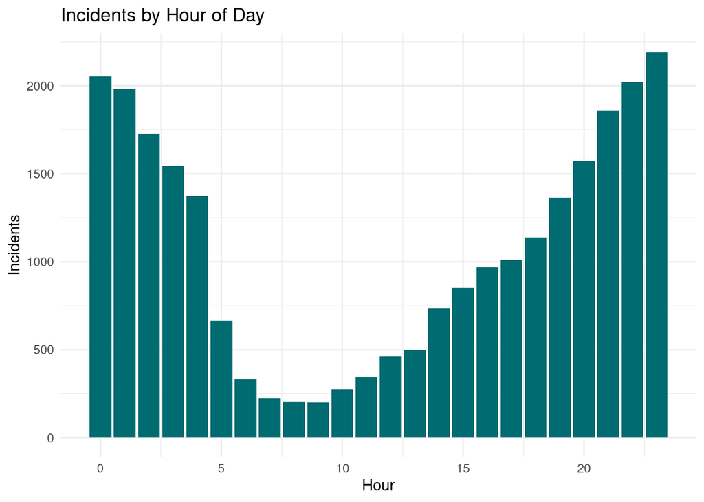

```r
viz_hours
```

#### Age groups

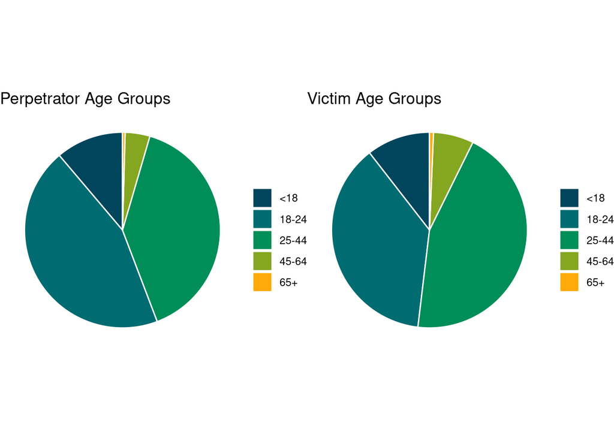

```r
grid.arrange(viz_age_perp, viz_age_vic, ncol=2)
```

As shown in above pie chart, most perpetrators as well as victims are between 18 and 44 years old. The distribution of age groups in victims and perpetrators is strikingly similar.

#### Racial background

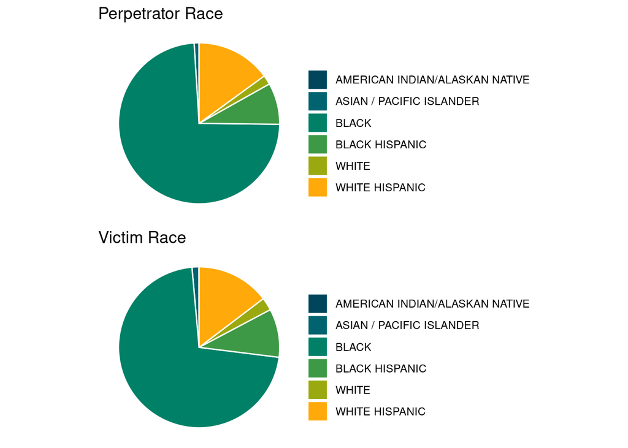

```r
grid.arrange(viz_race_perp, viz_race_vic, nrow=2)
```

Just as the they did in age groups, perpetrators and victims show a very similar distribution of racial backgrounds.

[figure not shown]

```r
viz_hypo
```

### Conclusion and Bias

One source of bias is a lack of deeper knowledge about New York and US crime statistics on my part. I am quite new to the US and all my knowledge about the crime scene is from news media, which in itself is often heavily biased. Another source is a lack on additional information. It would be interesting to know how racial backgrounds are distributed in the general population of New York, and what the reasons for the shootings were. The socioeconomic class would also be valuable information.